# R Laboratory 2

```r
library(lubridate)
library(ggplot2)
library(comprehenr)
```

**Exercise 1**

A set of measurements have been performed on the concentration of a contaminant in tap water. The following tables reports a set of values (x), with the corresponding probabilities given by the two methods (p1 and p2) Evaluate the expected values, E[X], and the variance, Var(X), for both methods

```r
x <- c(15.58, 15.9, 16, 16.1, 16.2)
p1 <- c(0.15, 0.21, 0.35, 0.15, 0.14)
p2 <- c(0.14, 0.05, 0.64, 0.08, 0.09)

cat("Expected value with method p1 ", sum(x*p1))
```

```
Expected value with method p1  15.959
```

```r
cat("Expected value with method p2 ", sum(x*p2))
```

```
Expected value with method p2  15.9622
```

```r
cat("Variance with method p1 ", ( sum(p1*(x^2)) - (sum(x*p1))^2 ))
```

```
Variance with method p1  0.033979
```

```r
cat("Variance with method p2 ", ( sum(p2*(x^2)) - (sum(x*p2))^2 ))
```

```
Variance with method p2  0.02816716
```

**Exercise 2**

• the waiting time, in minutes, at the doctor’s is about 30 minutes, and the distribution follows an exponential pdf with rate 1/30

1. simulate the waiting time for 50 people at the doctor’s office and plot the relative histogram
2. what is the probability that a person will wait for less than 10 minutes ?
3. evaluate the average waiting time from the simulated data and compare it with the expected value (calculated from theory and by manipulating the probability distributions using R)
4. what is the probability for waiting more than one hour before being received?

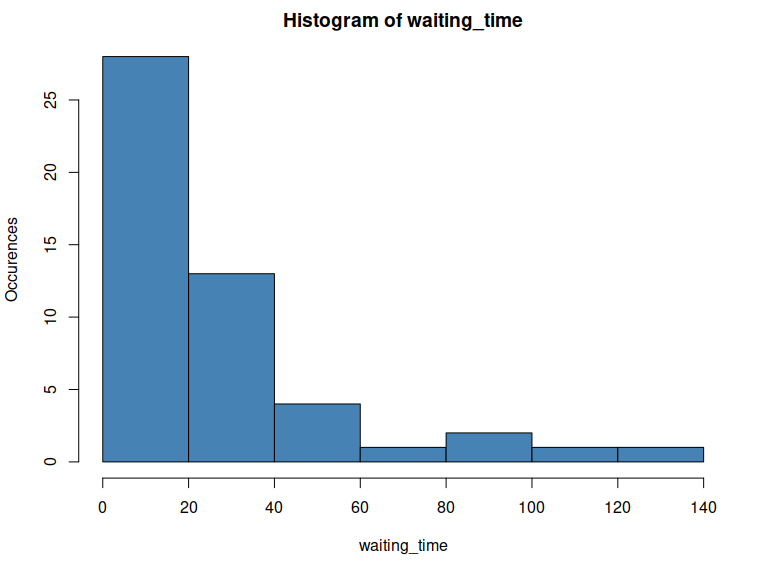

```r
# exponential pdf
#Dt=1 min

#A)
waiting_time <- rexp(50, rate=1/30)

hist(waiting_time, col="steelblue", ylab="Occurences")
```

```r
#-----------------
#B)
cat("The probability that a person will wait for less than 10 minutes is ", pexp(10 , rate=1/30)*100, "%")
```

```
The probability that a person will wait for less than 10 minutes is  28.34687 %
```

```r
#-----------------
#C)

exp_val_analysis <- mean(waiting_time)
expect_val_theo = 1/(1/30)   #from theory E[x] = 1/lambda
expect_val_distrib = integrate( function(x){ x*dexp(x, rate=1/30)}, 0 , +Inf)

cat("The expected value analysing the data is ", exp_val_analysis, ", from the theory ",expect_val_theo, ", from the distribution", expect_val_distrib[["value"]] ," ± ", round(expect_val_distrib[["abs.error"]], digits = 6))
```

```
The expected value analysing the data is  24.8593 , from the theory  30 , from the distribution 30  ±  2.5e-05
```

```r
#---------------
#D)
cat("The probability that a person will wait for more than 1 hour is ", (1 - pexp(60 , rate=1/30))*100, "%")
```

```
The probability that a person will wait for more than 1 hour is  13.53353 %
```

**Exercise 3**

• Let’s suppose that on a book, on average, there is one typo error every three pages. If the number of errors follows a Poisson distribution, plot the pdf and cdf, and calculate the probability that there is at least one error on a specific page of the book.

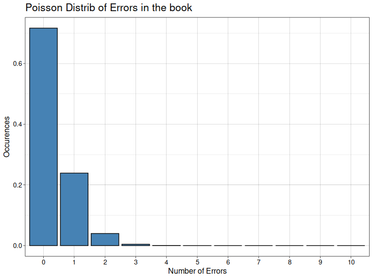

```r
#Dx=1 page

library(ggplot2)

rate <- 1/3
distr <- dpois(0:10, lambda=rate)
df <- data.frame((0:10) , distr)
colnames(df) <- c('x' , 'y')

plot <- ggplot(df , aes(x=factor(x), y=y))
plot <- plot + geom_bar(stat='identity', fill="steelblue", color='grey3') + theme_linedraw()
plot <- plot + ggtitle('Poisson Distrib of Errors in the book') + labs(x="Number of Errors", y="Occurences") +                       theme(plot.title = element_text(size=16),
                  axis.text.x = element_text(size=10),
                  axis.text.y = element_text(size=10),
                  axis.title.x = element_text(size=12),
                  axis.title.y = element_text(size=12)) + scale_x_discrete(breaks = 0:10)
plot
```

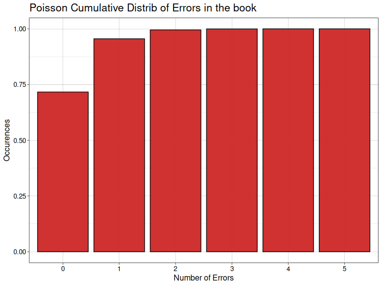

```r
#cumulative
cum_distr <- ppois(0:5, lambda=rate)
df2 <- data.frame((0:5) , cum_distr)
colnames(df2) <- c('x' , 'y')

plot <- ggplot(df2 , aes(x=factor(x), y=y))
plot <- plot + geom_bar(stat='identity', fill="firebrick3", color='grey3', alpha=0.95) + theme_linedraw()
plot <- plot + ggtitle('Poisson Cumulative Distrib of Errors in the book') + labs(x="Number of Errors", y="Occurences") + theme(plot.title = element_text(size=16),
                  axis.text.x = element_text(size=10),
                  axis.text.y = element_text(size=10),
                  axis.title.x = element_text(size=12),
                  axis.title.y = element_text(size=12)) + scale_x_discrete(breaks = 0:5)
plot
```

```r
#probability that there is at least one error on a specific page of the book
cat("The probability that there is at least one error on a specific page of the book is ", (1-distr[1])*100 , "%" )
```

```
The probability that there is at least one error on a specific page of the book is  28.34687 %
```

**Exercise 4**